# DATA 621 01[46893] : HomeWork1

### 6.0.3 Model 3 : Higher Order Stepwise Regression

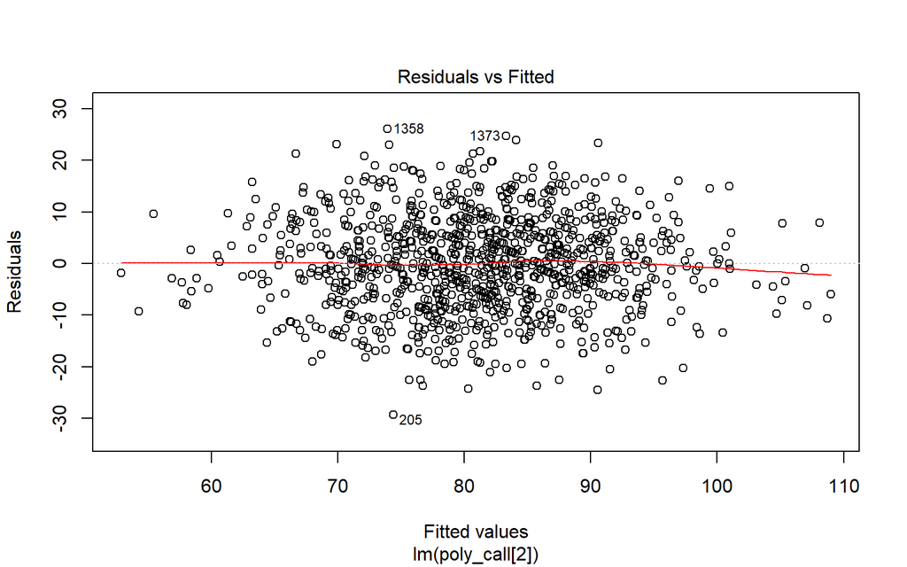

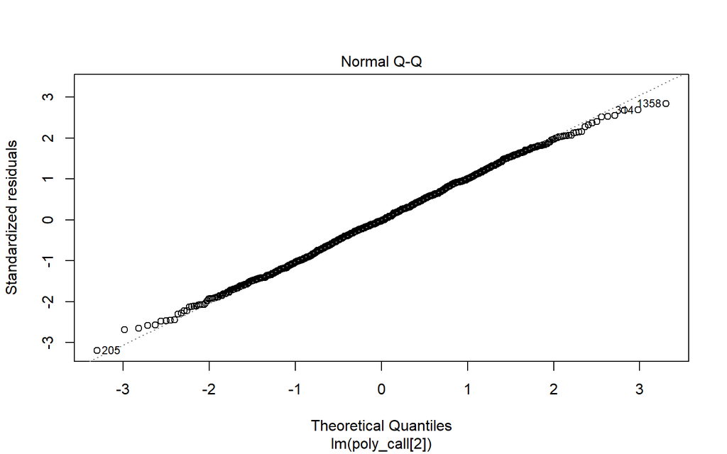

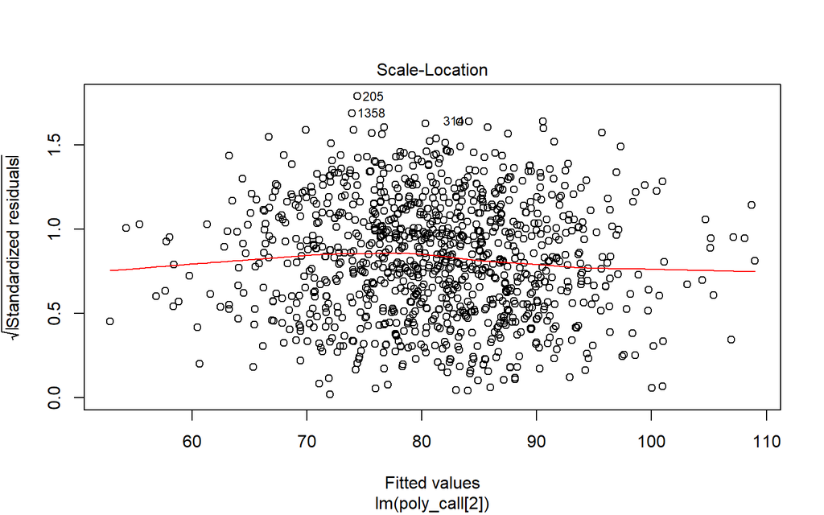

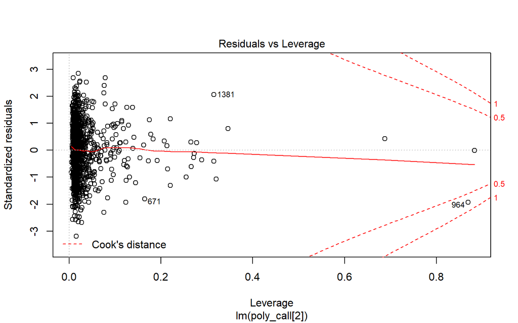

```r
plot(step_back)
```

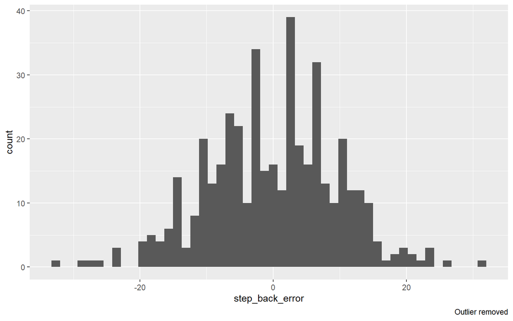

```r
moneyball_test$step_back <- round(predict(step_back, moneyball_test), 0)
moneyball_test <- moneyball_test %>%
                    mutate(step_back_error = TARGET_WINS - step_back)

moneyball_test %>%
  filter(step_back_error > -100) %>%
  ggplot(., aes(step_back_error)) +
  geom_histogram(bins = 50) +
  labs(caption = "Outlier removed")
```

```r
summary(moneyball_test$step_back_error)
```

```
##      Min.   1st Qu.    Median      Mean   3rd Qu.      Max.      NA's
## -32.00000  -7.00000   0.00000  -0.07143   7.00000  32.00000       247
```

# 7 CONCLUSION

This report covers an attempt to build a model to predict number of wins of a baseball team in a season based on several offensive and deffensive statistics. Resulting model explained about 36% of variability in the target variable and included most of the provided explanatory variables. Some potentially helpful variables were not included in the data set. For instance, number of At Bats can be used to calculate on-base percentage which may correlate strongly with winning percentage. The model can be revised with additional variables or further analysis.

```r
moneyball_test %>%
  select(kitchen_sink_error, simple_error, step_back_error) %>%
  summary() %>%
  kable() %>%
  kable_styling()
```

|  | kitchen_sink_error | simple_error | step_back_error |
| --- | --- | --- | --- |
|  | Min. :-28.3735 | Min. :-27.2876 | Min. :-32.00000 |
|  | 1st Qu.: -6.9033 | 1st Qu.: -7.6292 | 1st Qu.: -7.00000 |
|  | Median : -0.1124 | Median : 0.2432 | Median : 0.00000 |
|  | Mean : -0.0408 | Mean : -0.1372 | Mean : -0.07143 |
|  | 3rd Qu.: 6.4889 | 3rd Qu.: 6.5731 | 3rd Qu.: 7.00000 |
|  | Max. : 27.6495 | Max. : 29.6379 | Max. : 32.00000 |
|  | NA’s :247 | NA’s :143 | NA’s :247 |

Februray 1, 2020